# Nonparametric tests

Dr Juan H Klopper

## Preamble

In the previous chapter we learned that we cannot always use the common parametric tests to analyze our data.

This chapter is all about the proper alternatives. These non-parametric tests are not dependent upon the parameters that we saw in the assumptions for the use of parametric tests.

## The Wilcoxon rank-sum test

The Wilcoxon rank-sum test is used in place of the unpaired sample *t* test (Student’s *t* test). In this situation, the collected data point values do not meet the assumptions for the use of a parametric test. It is, very confusingly, also known as the *Mann-Whitney U test*, the *Wilcoxon-Mann-Whitney test* and the *Mann-Whitney-Wilcoxon test*.

Although the parametric assumptions are not required, this test does require that the data point values are ordinal in some way, i.e. that they can be ranked in order.

All the data point values from the two groups are placed in the same set and ranked in ascending order. The lowest value is assigned a rank of $1$ and so on, until the largest value, given the last (and highest) rank.

The groups are again separated and the ranks in each grouped summed. The null hypothesis is that these sums will be even in both groups. This means that it is equally likely that a randomly selected sample selected from one group will be less than or greater than a randomly selected sample from the other group.

Measurement capabilities and rounding do effect the Wilcoxon rank-sum test. If measurements are only accurate to a certain decimal value, two data point values will be given the same rank, even though they might not be equal given a more accurate measurement (more decimal values). Rounding of numerical values have a similar effect.

To investigate this test, we will create some simulated data and save it as a data frame object.

### Creating data

Below we create a data frame object with two statistical variables, `Group` and `CRP`. The former is nominal categorical with a sample space containing two elements. We will use this variable to construct two groups. The latter variable is numerical and consists of $100$ values following a $\chi^2$ distribution with a degrees of freedom value of $2$.

```r
set.seed(123)  # Seeding the pseudo-random number generator for reproducible results
group <- sample(c("A", "B"),
                100,
                replace = TRUE)

df <- data.frame(Group = group,
                 CRP = round(rchisq(100,
                                    2),
                             digits = 1))
```

We can view this first six rows using the `head()` function.

```r
head(df)
```

```
##   Group  CRP
## 1     A  1.4
## 2     B  1.0
## 3     A  3.5
## 4     B  1.4
## 5     B  0.1
## 6     A 10.4
```

### Conducting the test

The `wilcox.test()` function will conduct our Mann-Whitney-U tests. We use formula notation and separately defined the data frame object using the `data =` keyword argument. Note that we could also have used the `df$CRP ~ df$Group` syntax omitting the second argument.

```r
test1 <- wilcox.test(CRP ~ Group,
                     data = df)
```

Let’s look at the results of our test.

```r
test1
```

```
##
##  Wilcoxon rank sum test with continuity correction
##
## data:  CRP by Group
## W = 1342.5, p-value = 0.5048
## alternative hypothesis: true location shift is not equal to 0
```

We note a test statistic and a *p* value, which we can use in a similar fashion as the Student’s *t* test in our reports.

As and aside, the `wilcox.test()` function also allows the use of data stored in two separate lists.

```r
grpA <- rnorm(50,
              0,
              1)
grpB <- rchisq(50,
               1)

wilcox.test(grpA,
            grpB)
```

```
##
##  Wilcoxon rank sum test with continuity correction
##
## data:  grpA and grpB
## W = 636, p-value = 2.344e-05
## alternative hypothesis: true location shift is not equal to 0
```

### Effect size of the Wilcoxon sum-rank test

Effect size is used more commonly today. For the Mann-Whitney-U test, this can be calculated approximately, reverting the *p* value to a *z* score using the `qnorm()` command. The *z* score is then expressed as an *r* value using equation (5).

$$r = \frac{z}{\sqrt{n}} \tag{5}$$

### Example

Let’s look at an example of simulated data to see the process of choosing a non-parametric tests in action.

Given two groups, `Treatment` and `Control`, note the two sets of data point values for the variable `LDL`

```r
treatment <- c(1.8, 1.7, 6.9, 0.8, 2.1, 7.6)
contrl <- c(4.1, 3.2, 6.8, 1.9, 3.0, 4.7)
```

A Shapiro-Wilk test shows that the first group is not from a normal distribution.

```r
shapiro.test(treatment)
```

```
##
##  Shapiro-Wilk normality test
##
## data:  treatment
## W = 0.7845, p-value = 0.04244
```

To make life easier, we create a data frame object from our two lists.

Creating a `data.frame`

```r
df <- data.frame(LDL = c(treatment, contrl),
                 Group = rep(c("Treatment", "Control"),
                             each = 6))
head(df)
```

```
##   LDL     Group
## 1 1.8 Treatment
## 2 1.7 Treatment
## 3 6.9 Treatment
## 4 0.8 Treatment
## 5 2.1 Treatment
## 6 7.6 Treatment
```

Displaying a simple box plot gives us a great visual indicator of the data.

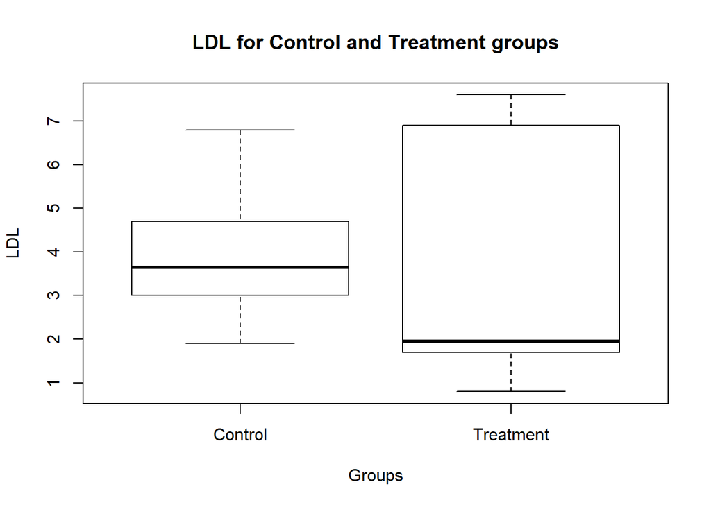

```r
boxplot(LDL ~ Group,
        df,
        main = "LDL for Control and Treatment groups",
        xlab = "Groups",
        ylab = "LDL")
```

The skewness in the data is clearly visible.

Now for conducting the Wilcoxon rank-sum test.

```r
wilcox.test(LDL ~ Group,
            data = df)
```

```
##
##  Wilcoxon rank sum test
##
## data:  LDL by Group
## W = 23, p-value = 0.4848
## alternative hypothesis: true location shift is not equal to 0
```

The $W$ statistic is the number of times that a data point value from the Treatment group is lower than that of the Control group.

Sorting the data point values makes this easier to understand.

```r
treatment <- sort(treatment)
contrl <- sort(contrl)
treatment
```

```
## [1] 0.8 1.7 1.8 2.1 6.9 7.6
```

```r
contrl
```

```
## [1] 1.9 3.0 3.2 4.1 4.7 6.8
```

## Wilcoxon signed-rank test

This is the non-parametric equivalent to the *paired-sample t test*.

The same `wilcox.test()` function is used for this test, except that the keyword argument `paired =` is set to `TRUE`.

## The Kruskal-Wallis test

The *Kruskal-Wallis test* is the non-parametric equivalent of analysis of variance. here we are comparing more than two groups.

Below we create data for a placebo groups and for two treatment groups, let’s say a low-dose and a high-dose group.

```r
treatment_low <- c(1.8, 1.7, 6.9, 0.8, 2.1, 7.6)
treatment_hi <- c(3, 4.2, 7, 4.5, 7.8, 3.3, 7.8)
contrl <- c(4.1, 3.2, 6.8, 1.9, 3.0, 4.7)
```

```r
kruskal.test(list(treatment_low,
                  treatment_hi,
                  contrl))
```

```
##
##  Kruskal-Wallis rank sum test
##
## data:  list(treatment_low, treatment_hi, contrl)
## Kruskal-Wallis chi-squared = 3.7195, df = 2, p-value = 0.1557
```

We note a Kruskal-Wallis $\chi^2$ statistic, degrees of freedom, and a *p* value.

## Nonparametric alternatives to correlation

The assumptions for the use of parametric tests applies to correlation. Both variables must meet these assumptions.

The first alternative ranks the values before calculating the correlation and is termed *Spearman correlation* and the resultant correlation coefficient is termed *Spearman’s* $\rho$. This can be passed as an argument to the `cor.test()` command.

First, we create some paired data point values for our correlation.

```r
height <- c(160, 167, 170, 168, 172, 159, 163, 155, 158, 180, 185, 181, 195)
weight <- height + (round((rnorm(length(height), 0, 1)), 3) * 10)
```

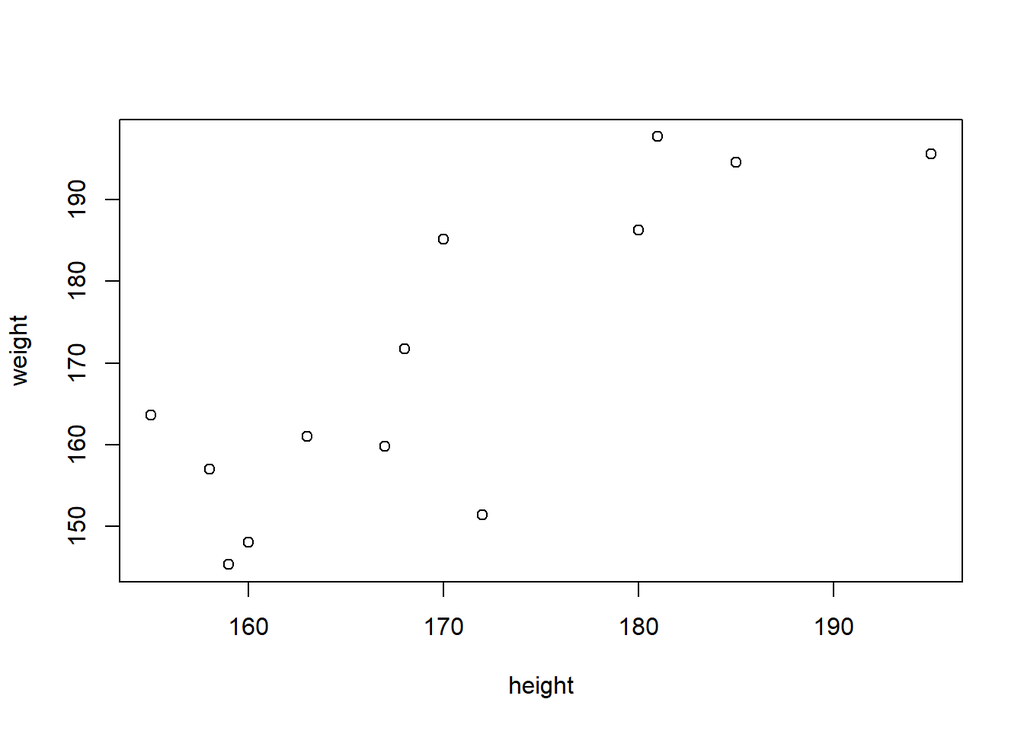

```r
plot(height,
     weight)
```

Now for the Spearman correlation test using the `method =` argument for the `cor.test()` function to `"Spearman"`.

```r
cor.test(height,
         weight,
         method = "spearman")
```

```
##
##  Spearman's rank correlation rho
##
## data:  height and weight
## S = 94, p-value = 0.00529
## alternative hypothesis: true rho is not equal to 0
## sample estimates:
##       rho
## 0.7417582
```

The correlation coefficient in this case is $\rho$. One problem with Spearman’s $\rho$ is that it deals poorly with small sample sizes and a large number of tied ranks. *Kendall’s* $\tau$ is an alternative non parametric test for these cases.

```r
cor.test(height,
         weight,
         method = "kendall")
```

```
##
##  Kendall's rank correlation tau
##
## data:  height and weight
## T = 62, p-value = 0.004289
## alternative hypothesis: true tau is not equal to 0
## sample estimates:
##       tau
## 0.5897436
```

## Conclusion

These are the non-parametric test alternatives for the commonly used parametric tests. Always check that the assumptions for the use of parametric tests are met. If not, do use these non-parametric alternatives.